# 12 Tables

In the previous chapters Chapter 9, Chapter 10 and Chapter 11, we covered in depth how you can use plots to communicate the results of your work. In this chapter, we introduce a second way to do so: using a table. In general, plots are often used to show trends over time (e.g. a line chart), a relationship (e.g. a scatter plot), to compare values across categories (e.g. a column of bar chart) or to show the full distribution of a variable (e.g. a boxplot or histogram). However, charts don’t always allow you to show exact or precise values. To see those values, people will have to look closely at the scales on the axis or the color/size/shape aesthetic you used. Doing so, they will usually not be able to assess precise values. To add those, you need to include labels or annotations. Doing so adds visual distractions to a chart and increases the risk that people don’t see the message of the plot: do you expect your audience to remember the trend of the exact values? Tables allows you to show precise values. Doing so, you can communicate e.g. the exact gross margin on a product. As long as the number of products is not too large, can can use a table to compare these margins across product categories or brands. In addition, you can add visual components including line- of fill colors, images, sparklines or other charts. However, tables are less suitable to show a large number of values.

In this chapter we will use {[gt](https://gt.rstudio.com/index.html)} (Iannone et al. (2025)) and {[gtExtras](https://jthomasmock.github.io/gtExtras/index.html)} (Mock (2024)). The first allows you to build the table. The second package adds a number of functions that allows you to e.g. select table themes or add charts, images or icons to a table. In addition to these two packages, there are various packages that you can use for specific purposes: {[gtsummary](https://www.danieldsjoberg.com/gtsummary/index.html)} (Sjoberg et al. (2021)) to generate tables allowing you to customize e.g. tables including estimates of regression models, summary statistics for data frames, … ; {[stargazer](https://cran.r-project.org/web/packages/stargazer/index.html)} (Hlavac (2022)) to show multiple regression models side-by-side (see e.g. [Princeton’s university library research guide](https://libguides.princeton.edu/R-stargazer)); {[flextable](https://davidgohel.github.io/flextable/index.html)} (Gohel and Skintzos (2024)) which can be used to create tables ready for Word or Powerpoint (see e.g. the [flextable gallery](https://ardata.fr/en/flextable-gallery/) or [flextable book](https://ardata-fr.github.io/flextable-book/)).

In this chapter we will introduce {gt} and {gtExtras}. As you’ll see, the workflow to create a table is largely in line with {ggplot2}’s workflow to create charts: there are functions to set the components of the table, to format the cells and functions to change e.g. colors (fill, text, lines). Often these function share a lot of similarities with their equivalent in {ggplot2}. For instance, to format numbers the {scales} package includes functions to deal with percentages, currencies, … . Similar functions are also part of {gt}; both include custom themes and both also allow to design your own theme, … . Because of these similarities and as most of these functions where introduced in Chapter 11 or Chapter 10, we will not cover the {gt} or {gtExtras} functions in depth. Using the online reference material (Iannone et al. (2025) and Mock (2024)) you should be able to use all arguments of most functions. Here, we will focus on those functions where the approach differs. There are many additional guides on {gt} and [gtExtrax] available on the internet: Nicola Rennie’s [Getting started with {gt} tables](https://nrennie.rbind.io/blog/getting-started-with-gt-tables/) includes an example of inserting charts using {ggplot2} in a table; [Riding tables with {gt} and {gtExtras}](https://bjnnowak.netlify.app/2021/10/04/r-beautiful-tables-with-gt-and-gtextras/) gives a nice illustration on how you can use {gt} and {gtExtras} to create a nice table with Tour de France riders and [Creating beautiful tables in R with {gt}](https://gt.albert-rapp.de/) illustrates the full workflow including options to finetune output. Tom Mock’s [gt cookbook](https://themockup.blog/static/resources/gt-cookbook.html) discusses all major options to build tables. In addition, on his blog [The Mockup](https://themockup.blog/) you’ll find many specific illustrations, e.g. [Beautiful tables in R with gtExtras](https://themockup.blog/posts/2022-06-13-gtextras-cran/), [Functions and themes for gt tables](https://themockup.blog/posts/2020-09-26-functions-and-themes-for-gt-tables/) and [10+ Guidelines for Better Tables in R](https://themockup.blog/posts/2020-09-04-10-table-rules-in-r/).

You installed {gt} in Chapter 1. You can now also install {gtExtras}:

```r
install.packages("gt", "gtExtras")
```

To use these packages, you have to load them

```r
library(gt)
library(gtExtras)
library(readr)
```

If you would like to learn how {gtsummary}, {stargazer} or {flextable} work, you need to install them first.

Before we start with {gt} and {gtExtras} we first introduce the components of a table.

## 12.1 Components of a table

A table has rows and columns, at their intersection, each table is divided in various cells. A table has various parts (Figure 12.1). Moving from the inside to the table to the outside, the table body refers to the cells that include the data. These cells can include numbers, characters, icons or images, charts, … . In Figure 12.1, you see that the table body also includes summary cells. The values in these summary cells can be included in your dataset or you can use {gt} to calculate these statistics. Moving up, the column labels show which variables are included in the cells of a column. These column labels may include the units of measurement (e.g. “usd”, “miles”, “hours”) if these would not be clear. Spanner column labels include labels that “span” multiple columns. For instance, if your dataset includes variables such as “sales (in units)”, “unit price” and “revenue” as well as “costs of goods sold” and “selling, general and administrative expenses” and “depreciation and amortization” you can include a spanner “revenues” above the first 3 columns and add a spanner “Operating costs” above the last three columns. You can have spanners at multiple levels: for instance: for each region in a country, you show the population and population density per city. Here, population and population density could be column labels. The level 1 spanner would include the city and the level 2 spanner - grouping cities across regions - would be the region. The stubs include the row labels and the group row labels. The allow you to “group” rows. For instance, if you have a dataset with income data for jobs (accountant, marketing manager, …) in various industries (banking, pharmaceuticals, automotive, retail, fashion, …) the group rows could show the industry and the rows the job. The cells to the right of the row labels include values; those to the right of the group row labels usually don’t. If the table includes summary statistics, their label (summary label) shows the statistics (e.g. average, median, …). The stub head shows which units are in the rows.

Figure 12.1: Components of a table

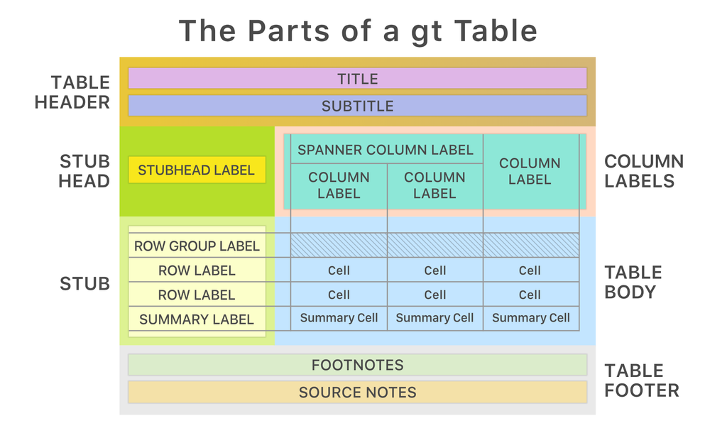

At the top of the table, you find the table header. This header includes the title and the subtitle. These should be short and explain what the type of data the table presents. If you need to add further explanatory notes, you can do so at the bottom of each table using one or more footnotes. These footnotes can be attached to a column or row label, a spanner column label, a row group label or an individual cell in the table body. The source notes allow you to add the source of the data. The footnotes and source notes are in the table footer. In addition, you can add a table caption, e.g. “table 1”.

Using {gt} you refer to these table components using a function that looks like `tab_"component"` (table_component of the table), e.g. `tab_header()`, `tab_spanner()`, `tab_row_group()`, `tab_stubhead()`, `tab_footnote()`, `tab_source_note()` and `tab_caption()`. The arguments of function follow from the component they refer to, e.g. `tab_header()` includes `title =` and `subtitle =` as it main argument; `tab_spanner()` includes the `label =` for the spanner, the columns who are part of the spanner in `columns =` and the `spanners =` for the spanners that should be spanned over in case you have more than one level of column spanners; `tab_footnote()` requires a text in `footnote =`, a location in `location =` and a placement where you want to add the footnote (to the right or the left of the data, label, …) `placement = c("auto", "right", "left")`. {gt} uses a similar strategy to identify the cells, e.g. `cells_title(groups = c(title", "subtitle"))` allows you to identify the title or subtitle; `cells_body(column = everything(), rows = everything())` allows you to identify one or more cells at the intersection of one or more rows and one or more columns and `cell_row_groups(groups = everyting())` will be used to identify one or more row group labels. Using these, you can target individual cells. For instance, to add a footnote to a table body cell on the 4th row in the 3rd column you can set the exact location using `tab_footnote(location = cells_body(column = 3, row = 4))`.

To identify rows and column you can also use <tidy-select> syntax. Recall from Chapter 8 that this syntax includes the following functions that allows you to select one or more columns (Henry and Wickham (2024)):

- `starts_with(match, ignore.case = FALSE, vars = NULL)`
- `ends_with(match, ignore.case = FALSE, vars = NULL)`
- `contains(match, ignore.case = FALSE, vars = NULL)`
- `matches(match, ignore.case = FALSE, vars = NULL)`

In all these functions `match` refers to an expression. If more than one expression is included, they should by included in `c()`. For the first three functions, the expression is exact (e.g. “var”, “new”, …). Using `match`you can also include regular expressions. The second argument, `ignore.case = FALSE` is familiar from other character functions. The last argument, `vars` allows you to include a vector of variable names. By default, the variable names are taken from the dataset.

- `num_range(prefix, range, suffix = "", width = NULL, vars = NULL)`

Using this function you can select variables such as `var1x`, `var2x` or `x001`, `x002`. To do so, you can include a prefix, e.g. “var”, a suffix (e.g. “x” in `var1x`) and a numerical range, e.g. 1:2. Adding a width allows you to select columns such as `x002` where width in this case is 3 (x002 includes three numbers: 0, 0 and 2).

- `everyting(vars = NULL)`

Select all columns or those in the vector `vars`.

- `last_col(offset = 0L, vars = NULL)`

Select the last column by default. If offset is different from zero (e.g. 10), this function selects the 10nd variable from the end. By default, this function selects the last column from the dataset.

- `group_cols()`

Select the columns that are used to group a dataset.

- `all_of()`, `any_of(x, vars = NULL)`

Here, x is a vector with variable names. R will select all columns that are included in this vector. The first is strict: if one of the names in the vector doesn’t appear in the data, R will return a error. The second doesn’t. If you add not, `!any_of` can be used to remove variables from a dataset.

- `where(fn)`

The argument `fn` refers to a function that returns TRUE or FALSE. For instance, to select all numeric columns, `where(is.numeric)` can be used. Likewise, to select all variables whose minimum is negative: `where(\(x) min(x) < 0)` would select these columns.

## 12.2 {gt}: workflow

As was the case with {ggplot2}, {gt} uses a data frame or tibble as its input. As you enter the data frame into the `gt()` function, R creates a gt table object: `gt_tbl`. Using the pipe operator `|>` you can start to add components, e.g. a title and subtitle, a footnote, column labels, … change the columns (e.g. merging or moving), format the columns using one of the `fmt_` functions `fmt_number()`, `fmt_currency()`, `fmt_percent()`, … change styling using `tab_style()`, `tab_style_body()` or one of the `opt_` functions. Using these you can change the font used to show the value or label in a cell using `cell_text()`, the fill color of the cell using `cell_fill()` or, using `cell_line()`, the lines at the top, bottom, left and right of each cell. If none of the styling options offer what you need, you can always use `tab_options()` to change any element of the table you would like. This last function is equivalent to the `themes()` function {ggplot2}. Note that there is one major difference with {ggplot2}: {gt} using the pipe operator while {ggplot2} used the `+`. The reason for this difference is that the latter adds layers following the grammar of graphics while the former creates a `gt_tbl` object. Using the pipe operator, you pipe this object in the next function. In addition, the workflow in {ggplot2} was more or less governed by the grammar of graphics: you first identity the data and aesthetics, select the geometry, change the scales and guides, add facets and adjust themes. As a matter of fact, without aesthetics, you can not adjust the scales or introduce facets. For a table, the workflow allows for more degrees of freedom. For instance, you could start with the header then move on to the column labels, spanner labels, row and row group labels then adjust the formatting of the numbers in the table body but you can also reverse the order and start with the formatting.

If you are satisfied with the output, you can save the table using `gtsave()`. This function allows you to save a table as a `docx`, `html`, `tex`, `rtf`, … file). In addition, you can use `as_word()` to save a table in an Open Office XML format that you can import in e.g. Word.

{gt} allows you to use html or markdown options for e.g. column labels or table headings. To do so, you include the html code in `html(text)` where text refers to the text that R needs to preserve as html output. Using `md(text)`, {gt} will interpret the `text` part as markdown formatting. Using this function it is easy to add quick styling. For instance adding you can add bold “**text**” using `md("**text**")`, italics “*text*” using `md("*text*")` and {gt} will in bold/italics “*text*” using `md("***text***")`.

To illustrate the workflow, we will use `life_table` as the main dataset. You can import the dataset from your raw data folder:

```r
life_table <- readr::read_csv(here::here("data", "raw", "life_table.csv"))
```

The data frame includes a random sample of 3 countries and 3 regions. It includes `iso2C`, `iso3c`, `country`, `region`, `1980_gdp_capita`, `2020_gdp_capita`, `1980_life_exp` and `2020_life_exp`. With 3 regions and 3 countries per region, we have sufficient data to illustrate most of {gt}’s functions.

### 12.2.1 Getting started

As a first step, you introduce the data frame in the `gt()` function. This function has a couple of arguments:

```r
gt(
  data,
  rowname_col = "rowname",
  groupname_col = dplyr::group_vars(data),
  process_md = FALSE,
  caption = NULL,
  rownames_to_stub = FALSE,
  row_group_as_column = FALSE,
  auto_align = TRUE,
  id = NULL,
  locale = getOption("gt.locale"),
  row_group.sep = getOption("gt.row_group.sep", " - ")
)
```

The `data` refer to the data frame or tibble. As this is the first argument of the function, you can use the pipe operator `|>` to introduce your dataset in this function. The next two arguments deal with the table stub. Using the first, you can include a column whose values will be used for the row labels. The second, `groupname_col` allows you to identify the column whose values will be used to add row group labels. Recall that a data frame can include row names. If this is the case, there is an alternative to add row labels: using `rownames_to_stub = TRUE` will add these row names as label to the plot. Using `row_group_as_column` you can determine if the row group labels will be put in a separate column. By default, this is not the case and they will be added in a dedicated row in the same column as the one that includes the row labels. The `locale` arguments includes the possibility to change, e.g. the language. Using this function with the `life_table` dataset and accepting all default values shows the `gt_tbl` object:

```r
life_table |> gt()
```

| iso2c | iso3c | country | region | 1980_gdp_capita | 1980_life_exp | 2020_gdp_capita | 2020_life_exp |
| --- | --- | --- | --- | --- | --- | --- | --- |
| CN | CHN | China | East Asia & Pacific | 430.8554 | 64.42000 | 10358.170 | 78.07700 |
| JP | JPN | Japan | East Asia & Pacific | 19334.3747 | 75.98902 | 34650.797 | 84.56000 |
| HK | HKG | Hong Kong SAR, China | East Asia & Pacific | 12553.2179 | 74.65341 | 41451.326 | 85.49634 |
| PT | PRT | Portugal | Europe & Central Asia | 10832.5150 | 71.21463 | 19778.714 | 80.97561 |
| BG | BGR | Bulgaria | Europe & Central Asia | 3431.5213 | 71.15756 | 7990.693 | 73.65854 |
| DE | DEU | Germany | Europe & Central Asia | 23977.2699 | 72.80032 | 42362.647 | 81.04146 |
| NI | NIC | Nicaragua | Latin America & Caribbean | 1850.0056 | 57.91400 | 1959.788 | 71.79500 |
| GT | GTM | Guatemala | Latin America & Caribbean | 3287.0240 | 56.02400 | 4005.839 | 71.79700 |
| TT | TTO | Trinidad and Tobago | Latin America & Caribbean | 8612.1558 | 67.57200 | 15789.614 | 74.40600 |

The table includes the variable names as column labels. The variable names are shown as they appear in the data. By default, {gt} also adds a number of horizontal lines: at the top and bottom of the column label cells and at the bottom of the table. The table doesn’t include any vertical lines. For now, we will remove the iso2c and iso3c columns. As we have the country name in the variable `country`, these variables don’t add value. To do so, we use the `select` function from {dplyr} and assign this data set to `life_table_gt`.

```r
life_table_gt <- life_table |>
  dplyr::select(country, region, starts_with(c("1980", "2020")))
```

The table now looks like

```r
life_table_gt |> gt()
```

| country | region | 1980_gdp_capita | 1980_life_exp | 2020_gdp_capita | 2020_life_exp |
| --- | --- | --- | --- | --- | --- |
| China | East Asia & Pacific | 430.8554 | 64.42000 | 10358.170 | 78.07700 |
| Japan | East Asia & Pacific | 19334.3747 | 75.98902 | 34650.797 | 84.56000 |
| Hong Kong SAR, China | East Asia & Pacific | 12553.2179 | 74.65341 | 41451.326 | 85.49634 |
| Portugal | Europe & Central Asia | 10832.5150 | 71.21463 | 19778.714 | 80.97561 |
| Bulgaria | Europe & Central Asia | 3431.5213 | 71.15756 | 7990.693 | 73.65854 |
| Germany | Europe & Central Asia | 23977.2699 | 72.80032 | 42362.647 | 81.04146 |
| Nicaragua | Latin America & Caribbean | 1850.0056 | 57.91400 | 1959.788 | 71.79500 |
| Guatemala | Latin America & Caribbean | 3287.0240 | 56.02400 | 4005.839 | 71.79700 |
| Trinidad and Tobago | Latin America & Caribbean | 8612.1558 | 67.57200 | 15789.614 | 74.40600 |

We can add row labels - labels that identify the observations in the rows - using the option `rowname_col`. Here, we can add the values in the variable `country` to use as row labels:

```r
life_table_gt |> gt(rowname_col = "country")
```

|  | region | 1980_gdp_capita | 1980_life_exp | 2020_gdp_capita | 2020_life_exp |
| --- | --- | --- | --- | --- | --- |
| China | East Asia & Pacific | 430.8554 | 64.42000 | 10358.170 | 78.07700 |
| Japan | East Asia & Pacific | 19334.3747 | 75.98902 | 34650.797 | 84.56000 |
| Hong Kong SAR, China | East Asia & Pacific | 12553.2179 | 74.65341 | 41451.326 | 85.49634 |
| Portugal | Europe & Central Asia | 10832.5150 | 71.21463 | 19778.714 | 80.97561 |
| Bulgaria | Europe & Central Asia | 3431.5213 | 71.15756 | 7990.693 | 73.65854 |
| Germany | Europe & Central Asia | 23977.2699 | 72.80032 | 42362.647 | 81.04146 |
| Nicaragua | Latin America & Caribbean | 1850.0056 | 57.91400 | 1959.788 | 71.79500 |
| Guatemala | Latin America & Caribbean | 3287.0240 | 56.02400 | 4005.839 | 71.79700 |
| Trinidad and Tobago | Latin America & Caribbean | 8612.1558 | 67.57200 | 15789.614 | 74.40600 |

Although the table didn’t change, much, there are some notable differences with the case where we didn’t add row names: the table now includes the country names as row labels but doesn’t add a stub head (the reference to “country” disappeared) and the table now includes a vertical line separating the row labels from the table body.

If the data include related observations, you can collect those related observations under a row group. In the example, the data frame includes a variable `region` which we can use to add row group labels. Doig so, the countries will be grouped according to their region and {gt} will add a row group label with the value for each region. To do so, we have multiple options:

- add the row group label in a dedicated row in the same column as the row labels:

```r
life_table_gt |> gt(groupname_col = "region")
```

| country | 1980_gdp_capita | 1980_life_exp | 2020_gdp_capita | 2020_life_exp |
| --- | --- | --- | --- | --- |
| East Asia & Pacific |  |  |  |  |
| China | 430.8554 | 64.42000 | 10358.170 | 78.07700 |
| Japan | 19334.3747 | 75.98902 | 34650.797 | 84.56000 |
| Hong Kong SAR, China | 12553.2179 | 74.65341 | 41451.326 | 85.49634 |
| Europe & Central Asia |  |  |  |  |
| Portugal | 10832.5150 | 71.21463 | 19778.714 | 80.97561 |
| Bulgaria | 3431.5213 | 71.15756 | 7990.693 | 73.65854 |
| Germany | 23977.2699 | 72.80032 | 42362.647 | 81.04146 |
| Latin America & Caribbean |  |  |  |  |
| Nicaragua | 1850.0056 | 57.91400 | 1959.788 | 71.79500 |
| Guatemala | 3287.0240 | 56.02400 | 4005.839 | 71.79700 |
| Trinidad and Tobago | 8612.1558 | 67.57200 | 15789.614 | 74.40600 |

- add the row group label in a new column:

```r
life_table_gt |> gt(groupname_col = "region", row_group_as_column = TRUE)
```

|  | country | 1980_gdp_capita | 1980_life_exp | 2020_gdp_capita | 2020_life_exp |
| --- | --- | --- | --- | --- | --- |
| East Asia & Pacific | China | 430.8554 | 64.42000 | 10358.170 | 78.07700 |
|  | Japan | 19334.3747 | 75.98902 | 34650.797 | 84.56000 |
|  | Hong Kong SAR, China | 12553.2179 | 74.65341 | 41451.326 | 85.49634 |
| Europe & Central Asia | Portugal | 10832.5150 | 71.21463 | 19778.714 | 80.97561 |
|  | Bulgaria | 3431.5213 | 71.15756 | 7990.693 | 73.65854 |
|  | Germany | 23977.2699 | 72.80032 | 42362.647 | 81.04146 |
| Latin America & Caribbean | Nicaragua | 1850.0056 | 57.91400 | 1959.788 | 71.79500 |
|  | Guatemala | 3287.0240 | 56.02400 | 4005.839 | 71.79700 |
|  | Trinidad and Tobago | 8612.1558 | 67.57200 | 15789.614 | 74.40600 |

For both options, including `rowname_col = "country"` would add the country names as row labels. Doing so, R would add a vertical lines between these labels and the table body. With one dedicated column per row group, the table would include two vertical lines: one separating the row group labels from the row labels and one separating the row labels from the table body.

Here, we used an existing variable in the table to add row groups. You can also create these groups without such a variable. To do so, you use the `tab_row_group()` function: `tab_row_group(data, label, rows, id = label)`. In addition to the data, this function needs a label for the row group (`label = ""`) and well as the rows to add to group (`rows =`). You can further specify an `id` for the row group. By default {gt} uses the label as id. If you add an id, e.g. `id = rg1`, you can use that id in subsequent operation, e.g. to style that row group. To identify rows, you can use e.g. <tidy-select> syntax or filter rows using boolean operators. To illustrate, we”ll add two groups: “high income” and “low income” and filter rows for the first group as those where 2020 per capita GDP is higher than 22000 and group countries whose 2020 per capita GDP is lower than or equal to 22000 under the “low income label). Note that the level (22000) is chosen arbitrarily. To add these labels we identify rows using `rows = '2020_gdp_capita > 22000` for the first label and `rows = '2020_gdp_capita <= 22000` for the second.

```r
life_table_gt |> gt() |>
  tab_row_group(
    group = "high income",
    rows = `2020_gdp_capita` > 22000) |>
  tab_row_group(
    group = "low income",
    rows = `2020_gdp_capita` <= 22000)
```

| country | region | 1980_gdp_capita | 1980_life_exp | 2020_gdp_capita | 2020_life_exp |
| --- | --- | --- | --- | --- | --- |
| low income |  |  |  |  |  |
| China | East Asia & Pacific | 430.8554 | 64.42000 | 10358.170 | 78.07700 |
| Portugal | Europe & Central Asia | 10832.5150 | 71.21463 | 19778.714 | 80.97561 |
| Bulgaria | Europe & Central Asia | 3431.5213 | 71.15756 | 7990.693 | 73.65854 |
| Nicaragua | Latin America & Caribbean | 1850.0056 | 57.91400 | 1959.788 | 71.79500 |
| Guatemala | Latin America & Caribbean | 3287.0240 | 56.02400 | 4005.839 | 71.79700 |
| Trinidad and Tobago | Latin America & Caribbean | 8612.1558 | 67.57200 | 15789.614 | 74.40600 |
| high income |  |  |  |  |  |
| Japan | East Asia & Pacific | 19334.3747 | 75.98902 | 34650.797 | 84.56000 |
| Hong Kong SAR, China | East Asia & Pacific | 12553.2179 | 74.65341 | 41451.326 | 85.49634 |
| Germany | Europe & Central Asia | 23977.2699 | 72.80032 | 42362.647 | 81.04146 |

Using boolean operators, you can add more refined row groups, e.g. `rows = var1 < x & (var2 > y | var3 < z)` would collect rows where the first variable is smaller than x and the second variable is larger than y or the third variable is smaller than z.

```r
cols_move(data, columns, after)
```

Here you can identify the columns you like to move as well as a location using `after`. You can identify the columns referring to their name, include them in a vector or use <tidy-select> syntax. For instance, to move the column “2020_gdp_capita” after “1980_gdp_capita” and using <tidy-select> syntax (`starts_with()`):

```r
life_table_gt |> gt() |> cols_move(starts_with("2020_gdp"), after = `1980_gdp_capita`)
```

| country | region | 1980_gdp_capita | 2020_gdp_capita | 1980_life_exp | 2020_life_exp |
| --- | --- | --- | --- | --- | --- |
| China | East Asia & Pacific | 430.8554 | 10358.170 | 64.42000 | 78.07700 |
| Japan | East Asia & Pacific | 19334.3747 | 34650.797 | 75.98902 | 84.56000 |
| Hong Kong SAR, China | East Asia & Pacific | 12553.2179 | 41451.326 | 74.65341 | 85.49634 |
| Portugal | Europe & Central Asia | 10832.5150 | 19778.714 | 71.21463 | 80.97561 |
| Bulgaria | Europe & Central Asia | 3431.5213 | 7990.693 | 71.15756 | 73.65854 |
| Germany | Europe & Central Asia | 23977.2699 | 42362.647 | 72.80032 | 81.04146 |
| Nicaragua | Latin America & Caribbean | 1850.0056 | 1959.788 | 57.91400 | 71.79500 |
| Guatemala | Latin America & Caribbean | 3287.0240 | 4005.839 | 56.02400 | 71.79700 |
| Trinidad and Tobago | Latin America & Caribbean | 8612.1558 | 15789.614 | 67.57200 | 74.40600 |

The second option would be to use {dplyr}’s `relocate()` function and change the data frame used to pipe into `gt()`:

```r
life_table_gt <- life_table_gt |>
  dplyr::relocate(`2020_gdp_capita`, .after = `1980_gdp_capita`)
```

### 12.2.2 Formatting

The dataset includes two variables measured in USD (per capita gdp for 1980 and 2020) and two numeric variables. As you could in {ggplot2}, e.g. using {scales} (see Chapter 11), you can add formatting of various “standard” formats in {gt} as well. For instance, using `fmt_currency()` and `fmt_number()` you can change the formatting of values in the columns that include currency or numeric values. Before we do so to format the table, let’s review the arguments of the latter function:

```r
fmt_number(
  data,
  columns = everything(),
  rows = everything(),
  decimals = 2,
  n_sigfig = NULL,
  drop_trailing_zeros = FALSE,
  drop_trailing_dec_mark = TRUE,
  use_seps = TRUE,
  accounting = FALSE,
  scale_by = 1,
  suffixing = FALSE,
  pattern = "{x}",
  sep_mark = ",",
  dec_mark = ".",
  force_sign = FALSE,
  system = c("intl", "ind"),
  locale = NULL
)
```

The first three arguments should be familiar: they allow to identify the data as well as the columns and rows. By default, {gt} using `everything()`. In other words `fmt_number()` formats all rows of every column. If you add specific columns, e.g. using one of the <tidy-select> helper functions, the column name, a vector with column names of their column number, {gt} will format all rows for these columns. Likewise, if you identify a specific rows, R will format all columns for each of these rows. Setting both, R will format the cells that are at the intersection of the identified columns and rows. The next 6 arguments allow you to specify the number of decimals, the number of significant figures, to determine if the table needs to drop trailing zero’s (redundant zeros after the decimal mark), if the the table needs to drop trailing decimal marks (if FALSE, the table will show 15. and not 15), if there is a thousand separator identified in `sep_mark =` (different from the one in the locale) and if the table needs to show negative values within brackets (`accounting = TRUE`). The `scale` argument works as it did in {ggplot2}. As an alternative to `scale`, you can use `suffixing`. Here you can supply {gt} with `T` (trillion), `B` (billion) `M` (million) and`K` (thousand). R will scale the values accordingly and add a suffix. For instance, using `suffixing = "M"`, the table will show 7.5M if the data includes 7500000. As an alternative, you can add `suffixing = TRUE` and R will determine the appropriate scale factor. If you specify a pattern using `{x}` for the value, the table will show that pattern e.g. the pattern “approx {x}” would add “approx” to every value. The arguments `sep_mark`and `dec_mark` allow you to specify the decimal mark (by default a dot) and the thousand separator (by default a comma). If you change the locale, these default values will change. However, adding a specif mark here overrules the locale. If you want to add a plus sign to positive values, you can change the value `force_sign` from FALSE into TRUE. For the system, by default it used the international system where thousands are separated (i.e. three digits). The alternative is the Indian system.

The arguments of `fmt_currency()` are very similar

```r
fmt_currency(
  data,
  columns = everything(),
  rows = everything(),
  currency = NULL,
  use_subunits = TRUE,
  decimals = NULL,
  drop_trailing_dec_mark = TRUE,
  use_seps = TRUE,
  accounting = FALSE,
  scale_by = 1,
  suffixing = FALSE,
  pattern = "{x}",
  sep_mark = ",",
  dec_mark = ".",
  force_sign = FALSE,
  placement = "left",
  incl_space = FALSE,
  system = c("intl", "ind"),
  locale = NULL
)
```

Here, the argument `use_subunits = TRUE` shows sub-units, e.g. cent for the Euro. Changing this into `FALSE` removes these sub-units e.g. €15.12. becomes €15. {gt} includes a wide range of currencies and symbols. To add the Euro symbol for instance, you can use `currency = "EUR"`. Doing so, R will add a “€” sign to the values in the columns and rows. By default, it will add these symbols left. To change that into right you can change `placement = "left"` into `"right"`. R supports the following symbols:

```r
info_currencies(type = "symbol")
```

Currencies Supported in **gt**

Currency symbols are used in the `fmt_currency()` function.

| Currency Symbol Keyword | Formatted Currency |
| --- | --- |
| dollar | $49.95 |
| euro | €49.95 |
| pound | £49.95 |
| yen | ¥49.95 |
| franc | ₣49.95 |
| lira | ₤49.95 |
| peseta | ₧49.95 |
| won | ₩49.95 |
| sheqel | ₪49.95 |
| dong | ₫49.95 |
| kip | ₭49.95 |
| tugrik | ₮49.95 |
| drachma | ₯49.95 |
| peso | ₱49.95 |
| guarani | ₲49.95 |
| austral | ₳49.95 |
| hryvnia | ₴49.95 |
| cedi | ₵49.95 |
| rupee | ₹49.95 |
| generic | ¤49.95 |

To see which currencies {gt} supports, you can use `info_currencies(begins_with = )`. For instance, to show all currencies that start with “a”:

```r
info_currencies(begins_with = "a")
```

Currencies Supported in **gt**

Currency codes are used in the `fmt_currency()` function

| Currency Name | Alpha Code | Numeric Code | No. of Subunits | Formatted Currency |
| --- | --- | --- | --- | --- |
| United Arab Emirates dirham | AED | 784 | 2 | DH49.95 |
| Afghan afghani | AFN | 971 | 2 | ؋49.95 |
| Albanian lek | ALL | 8 | 2 | Lek49.95 |
| Armenian dram | AMD | 51 | 2 | AMD49.95 |
| Netherlands Antillean guilder | ANG | 532 | 2 | NAƒ49.95 |
| Angolan kwanza | AOA | 973 | 2 | Kz49.95 |
| Argentine peso | ARS | 32 | 2 | $49.95 |
| Australian dollar | AUD | 36 | 2 | $49.95 |
| Aruban florin | AWG | 533 | 2 | ƒ49.95 |
| Azerbaijani manat | AZN | 944 | 2 | ₼49.95 |

Using the three digit alpha code, R will show the currencies with their symbol.

There are many other `fmt_` function including e.g. `fmt_percent`, `fmt_date`, `fmt_time`, `fmt_datetime` for the date and time (for the style for date/time options, see the guide in the {gt}’s [online material](https://gt.rstudio.com/reference/fmt_datetime.html)), `fmt_fraction`, `fmt_roman` (to show Roman number, e.g. IV, XII) and a general `fmt()` function. Here, you can add a function e.g. `paste` (e.g. `fns = \(x) paste("[", x/2, "]")` to divide the values by 2 and add square brackets. For these function, most of the arguments follow from their format and you can use Iannone et al. (2025) to see them.

To illustrate using `live_table_gt` let’s add a currency format to the gdp variables and a number format to the life expectancy format. In both cases, we will show two decimals. For the currency, we will use the dollar and add a white space as separator mark:

```r
life_table_gt |> gt() |>
  fmt_currency(
    columns = 3:4,
    decimals = 2,
    currency = "USD",
    sep_mark = " ") |>
  fmt_number(
    columns = contains("life"),
    decimals = 2)
```

| country | region | 1980_gdp_capita | 2020_gdp_capita | 1980_life_exp | 2020_life_exp |
| --- | --- | --- | --- | --- | --- |
| China | East Asia & Pacific | $430.86 | $10 358.17 | 64.42 | 78.08 |
| Japan | East Asia & Pacific | $19 334.37 | $34 650.80 | 75.99 | 84.56 |
| Hong Kong SAR, China | East Asia & Pacific | $12 553.22 | $41 451.33 | 74.65 | 85.50 |
| Portugal | Europe & Central Asia | $10 832.52 | $19 778.71 | 71.21 | 80.98 |
| Bulgaria | Europe & Central Asia | $3 431.52 | $7 990.69 | 71.16 | 73.66 |
| Germany | Europe & Central Asia | $23 977.27 | $42 362.65 | 72.80 | 81.04 |
| Nicaragua | Latin America & Caribbean | $1 850.01 | $1 959.79 | 57.91 | 71.80 |
| Guatemala | Latin America & Caribbean | $3 287.02 | $4 005.84 | 56.02 | 71.80 |
| Trinidad and Tobago | Latin America & Caribbean | $8 612.16 | $15 789.61 | 67.57 | 74.41 |

To change the currency values using suffixing and show life expectancy with 1 significant digit after the decimal we can use `suffixing = TRUE` in the currency formatting function and `n_sigfig = 3` in the number formatting function.

```r
life_table_gt |> gt() |>
  fmt_currency(
    columns = 3:4,
    decimals = 2,
    currency = "USD",
    suffixing = TRUE) |>
  fmt_number(
    columns = contains("life"),
    n_sigfig = 3)
```

| country | region | 1980_gdp_capita | 2020_gdp_capita | 1980_life_exp | 2020_life_exp |
| --- | --- | --- | --- | --- | --- |
| China | East Asia & Pacific | $430.86 | $10.36K | 64.4 | 78.1 |
| Japan | East Asia & Pacific | $19.33K | $34.65K | 76.0 | 84.6 |
| Hong Kong SAR, China | East Asia & Pacific | $12.55K | $41.45K | 74.7 | 85.5 |
| Portugal | Europe & Central Asia | $10.83K | $19.78K | 71.2 | 81.0 |
| Bulgaria | Europe & Central Asia | $3.43K | $7.99K | 71.2 | 73.7 |
| Germany | Europe & Central Asia | $23.98K | $42.36K | 72.8 | 81.0 |
| Nicaragua | Latin America & Caribbean | $1.85K | $1.96K | 57.9 | 71.8 |
| Guatemala | Latin America & Caribbean | $3.29K | $4.01K | 56.0 | 71.8 |
| Trinidad and Tobago | Latin America & Caribbean | $8.61K | $15.79K | 67.6 | 74.4 |

Here, you can see that {gt} scales the values with 1/1000 and adds a “K”. For the number of years, the table now shows 1 digit after the decimal sign and R rounded using the usual rounding rules (Chapter 3).

There are a couple of useful functions to deal with missing values, zeros or very large and very small values. The first `sub_missing()` allows you to substitute missing values with a different character. By default the table will show “—”, however, you can change that if you add a specific character or white space. As with all other functions, you can use this substitution for specific columns/rows. A similar function is `sub_zero()`. This function allows you to replace “0”-s in the table. By default the table will add “nil”. Using `sub_small_vals()` you can substitute small values, i.e. values below a threshold which you can set as one of this function’s arguments with a alternative pattern, e.g. “<0.01”. By default, R uses 0.01 as a threshold and changes all values smaller than this threshold to “<0.01”. In other words, 0.0025, 0.00025 will all be set to “<0.01”. In a table that includes significance levels for e.g. a t-statistics or regression estimates, this is a useful way to change values such as 0.0000 into “<0.01”. `sub_large_vals()` performs a similar calculations for very large values.

In addition to the format, you can also align the columns left, right or center. To do so, you can use `cols_align(align = , columns = )` where you add “left”, “center” or “right” after align and identify the columns after the `columns =` argument e.g. using the <tidy-select> syntax, a vector with column names or a vector with column positions. For numeric values, you can further use `cols_align_decimal(columns = , dec_mark = ".", locale = )`. Using this function {gt} will align the columns using the decimal mark specified in `dec_mark =` or the decimal mark that follows from the `locale` argument. This last function is usually only relevant if you didn’t specify the number of decimals and the number of decimals is different for the elements in the column’s cells. To illustrate, we’ll align the numeric columns using `cols_align_decimal` and the character columns using `cols_align`. Using the latter, we’ll center the character columns:

```r
life_table_gt |> gt() |>
  fmt_currency(
    scale_by = 1,
    columns = 3:4,
    currency = "USD") |>
  fmt_number(
    columns = contains("life"),
    decimals = 2) |>
  cols_align(
    columns =  where(is.character),
    align = "center") |>
  cols_align_decimal(
    columns = where(is.numeric))
```

| country | region | 1980_gdp_capita | 2020_gdp_capita | 1980_life_exp | 2020_life_exp |
| --- | --- | --- | --- | --- | --- |
| China | East Asia & Pacific | $430.86 | $10,358.17 | 64.42 | 78.08 |
| Japan | East Asia & Pacific | $19,334.37 | $34,650.80 | 75.99 | 84.56 |
| Hong Kong SAR, China | East Asia & Pacific | $12,553.22 | $41,451.33 | 74.65 | 85.50 |
| Portugal | Europe & Central Asia | $10,832.52 | $19,778.71 | 71.21 | 80.98 |
| Bulgaria | Europe & Central Asia | $3,431.52 | $7,990.69 | 71.16 | 73.66 |
| Germany | Europe & Central Asia | $23,977.27 | $42,362.65 | 72.80 | 81.04 |
| Nicaragua | Latin America & Caribbean | $1,850.01 | $1,959.79 | 57.91 | 71.80 |
| Guatemala | Latin America & Caribbean | $3,287.02 | $4,005.84 | 56.02 | 71.80 |
| Trinidad and Tobago | Latin America & Caribbean | $8,612.16 | $15,789.61 | 67.57 | 74.41 |

### 12.2.3 Labels, headers, footnotes and sources

Before we continue, let’s first assign the formatted table to an object `life_table_gt_form`. Doing so, we can use this table object with formatted columns as the starting point in our code. Here, we will use 2 decimals for both the number of currency format:

```r
life_table_gt_form <- life_table_gt |> gt() |>
  fmt_currency(
    columns = 3:4,
    decimals = 2,
    currency = "USD") |>
  fmt_number(
    columns = contains("life"),
    decimals = 2)
```

The table includes the variable names as they appear in the data set. To change the column labels, you can use `cols_label()`. Here, you have two options. The first is to add labels of each column where you would like to change the label. To illustrate Markdown, we’ll add bold to the label for the variables `country` and `region` and change the other ones referring only to their years and written in italics. To add these bold and italic fonts, using `md()` you add the part you would like in bold between double stars and the parts you would like in italics between single stars. For every `old name` you include a `new name` using `old name = new name`:

```r
life_table_gt_form |>
  cols_label(
    country = md("**Country**"),
    region = md("**Region**"),
    `1980_gdp_capita` = md("*1980*"),
    `2020_gdp_capita` = md("*2020*"),
    `1980_life_exp` = md("*1980*"),
    `2020_life_exp` = md("*2020*"))
```

| **Country** | **Region** | *1980* | *2020* | *1980* | *2020* |
| --- | --- | --- | --- | --- | --- |
| China | East Asia & Pacific | $430.86 | $10,358.17 | 64.42 | 78.08 |
| Japan | East Asia & Pacific | $19,334.37 | $34,650.80 | 75.99 | 84.56 |
| Hong Kong SAR, China | East Asia & Pacific | $12,553.22 | $41,451.33 | 74.65 | 85.50 |
| Portugal | Europe & Central Asia | $10,832.52 | $19,778.71 | 71.21 | 80.98 |
| Bulgaria | Europe & Central Asia | $3,431.52 | $7,990.69 | 71.16 | 73.66 |
| Germany | Europe & Central Asia | $23,977.27 | $42,362.65 | 72.80 | 81.04 |
| Nicaragua | Latin America & Caribbean | $1,850.01 | $1,959.79 | 57.91 | 71.80 |
| Guatemala | Latin America & Caribbean | $3,287.02 | $4,005.84 | 56.02 | 71.80 |
| Trinidad and Tobago | Latin America & Caribbean | $8,612.16 | $15,789.61 | 67.57 | 74.41 |

The table now shows new column labels: “1980”, “2020”, “1980” and “2020”. There is a second way to change column labels. Most variable names in a dataset include a part which you can use for your labels. In `1980_life_exp` for instance, the variable name includes “1980” but also “life”, “exp” or “life_exp”. We can use these parts to build column labels. To do so, we first extract the column names from the dataset using `colnames()`. The result is a vector that includes the variable names as they appear in the data. We can now extract the parts of these names that we need. For instance, in this dataset, we need the 1980 and 2020. To extract these parts, we can use one of the string function (Chapter 3 or Chapter 4). Here we can use e.g. `stringr::str_remove()` to remove the part “_gdp_capita” and “life_exp”. As an alternative, you can use `str_extract_all()` or `grep(value = TRUE)` to extract the strings you want to include in the labels of the variables. We now have a vector with names we like to include in the table. Using this vector, we can add formatting. Here, we do so using `str_to_title`, alternatives are `toupper`, `tolower` … or you can replace e.g. `life` by “life expectancy” using a string replace function. The result is a vector with variables names as we would like them in the table. In the last step, we create a named vector where the names of the variables as they appear in the data are used to name the labels we want in the table. Do do so, we use `names()` to add names to the `names_for_table` vector. The result is a vector where the column names are the names as they appear in the dataset and the values are the names as they should be used in the table.

```r
names_in_data <- colnames(life_table_gt)
names_for_table <- names_in_data |> stringr::str_remove("_[a-z]+_[a-z]+")
names_for_table <- names_for_table |> stringr::str_to_title()
names(names_for_table) <- names_in_data
```

We can now use this vector, `names_for_table` in the `cols_label()` argument. To do so, we add `.list = names_for_table`. Using this named vector, R will use the names of every column to identify the names as they appear in the dataset. If there is a match with the names in the dataset, R will replace these names with the values in the vector. In other words, it will replace the names as they appear in the data with the names as they should show in the table. If there is no match, R will not changese these labels.

```r
life_table_gt_form |>
  cols_label(.list = names_for_table)
```

| Country | Region | 1980 | 2020 | 1980 | 2020 |
| --- | --- | --- | --- | --- | --- |
| China | East Asia & Pacific | $430.86 | $10,358.17 | 64.42 | 78.08 |
| Japan | East Asia & Pacific | $19,334.37 | $34,650.80 | 75.99 | 84.56 |
| Hong Kong SAR, China | East Asia & Pacific | $12,553.22 | $41,451.33 | 74.65 | 85.50 |
| Portugal | Europe & Central Asia | $10,832.52 | $19,778.71 | 71.21 | 80.98 |
| Bulgaria | Europe & Central Asia | $3,431.52 | $7,990.69 | 71.16 | 73.66 |
| Germany | Europe & Central Asia | $23,977.27 | $42,362.65 | 72.80 | 81.04 |
| Nicaragua | Latin America & Caribbean | $1,850.01 | $1,959.79 | 57.91 | 71.80 |
| Guatemala | Latin America & Caribbean | $3,287.02 | $4,005.84 | 56.02 | 71.80 |
| Trinidad and Tobago | Latin America & Caribbean | $8,612.16 | $15,789.61 | 67.57 | 74.41 |

The column labels are set. We can now add spanner columns. To do so, we use `tab_spanner()`. To add these spanners, we have to identify to columns for each spanner. To do so, we use the <tidy-select> helpers. For instance, using `contains("gdp")` to identify all columns for the first spanner, R will “year_per capita gdp”. For the second spanner using we use `contains("life")` to collect all the “year_life expectancy” columns. There are many alternatives: you can refer to the columns by their number (e.g. c(3, 4), 3:4) or in a vector by their (old) name. The spanner label is added after the `label` argument in `tab_spanner()`. Here,we use Markdown (`md()`) to show them in bold by including the label between **. As an alternative, you can use a traditional “character label” and add styling later.

```r
life_table_gt_form |>
  cols_label(.list = names_for_table) |>
  tab_spanner(
    label = md("**Per capita GDP**"),
    columns = contains("gdp")) |>
  tab_spanner(
    label = md("**Life expectancy**"),
    columns = c(`1980_life_exp`, `2020_life_exp`))
```

| Country | Region | **Per capita GDP** 1980 | **Per capita GDP** 2020 | **Life expectancy** 1980 | **Life expectancy** 2020 |
| --- | --- | --- | --- | --- | --- |
| China | East Asia & Pacific | $430.86 | $10,358.17 | 64.42 | 78.08 |
| Japan | East Asia & Pacific | $19,334.37 | $34,650.80 | 75.99 | 84.56 |
| Hong Kong SAR, China | East Asia & Pacific | $12,553.22 | $41,451.33 | 74.65 | 85.50 |
| Portugal | Europe & Central Asia | $10,832.52 | $19,778.71 | 71.21 | 80.98 |
| Bulgaria | Europe & Central Asia | $3,431.52 | $7,990.69 | 71.16 | 73.66 |
| Germany | Europe & Central Asia | $23,977.27 | $42,362.65 | 72.80 | 81.04 |
| Nicaragua | Latin America & Caribbean | $1,850.01 | $1,959.79 | 57.91 | 71.80 |
| Guatemala | Latin America & Caribbean | $3,287.02 | $4,005.84 | 56.02 | 71.80 |
| Trinidad and Tobago | Latin America & Caribbean | $8,612.16 | $15,789.61 | 67.57 | 74.41 |

The table includes column and spanner labels. Now we can add a header using `tab_header()` and a source using `tab_source_note()`. The first allows you to set a title and a subtitle after the `title =` and `subtitle =` arguments. For the second, you add the text of the note after the `source_note` argument. To add a footnote, {gt} includes the `tab_footnote()` function. Here, you have to add the text of the footnote after the `footnote` argument as well as the location and the placement of the footnote. For the first, you have to identify where you want to show the footnote. Do so so, you can use e.g `cells_title(groups = "title" or "subtitle")` to add a note to the title or subtitle, `cells_stubhead()` to add the footnote to the stub head, `cells_column_labels(columns = )` to add a note to one or more column labels identified in `columns`, `cells_column_spanner(spanners = )` to add a note to one or more column spanners, … . Here we will add a note to the data for Germany for 1980 to explain that these data refer to Western Germany. To do so we use `cells_body()` and use the `columns` and `rows` argument to identify the exact table body cells. The note should be added to the columns including (“1980”) and the rows that show data for Germany. Here, we will add the names of the columns in a vector. Note that `starts_with("1980")`, `contains("1980")`, … could have been used as an alternative. For the rows, we identify them using `rows = country == "Germany"`. Note that for the last argument, you start with `rows =` and then add the condition `column == value`. The condition can include multiple boolean operations. With respect to the placement, you can add the footnote reference “right” or “left” of the content of the cell. By default, R uses numbers. You can change these marks using `tab_options(footnotes.marks = )`. Here, you can add e.g. `letters`, `LETTERS`, `extended` or `standard`. The first two use the letters vectors and add lower or upper case letters while the last two use symbols: an Asterisk, a dagger, a double dagger, a section sign, a double vertical line and a paragraph sign. The first, `extended` uses all 6, the second uses only the first four. To add the headers, source note and footnote to the table and using numbers for footnote marks, we add these to the previous table:

```r
life_table_gt_form |>
  cols_label(.list = names_for_table) |>
  tab_spanner(
    label = md("**Per capita GDP**"),
    columns = contains("gdp")) |>
  tab_spanner(
    label = md("**Life expectancy**"),
    columns = c(`1980_life_exp`, `2020_life_exp`)) |>
  tab_header(
    title = "GDP per capita and life expectancy at birth",
    subtitle = "Selected countries and years") |>
  tab_source_note(
    source_note = "Source: World Bank Development indicators") |>
  tab_footnote(
    footnote = "Data prior to 1991 refer to Western Germany (GDR)",
    cells_body(columns = c(`1980_gdp_capita`, `1980_life_exp`), rows = country == "Germany"),
    placement = "right")
```

GDP per capita and life expectancy at birth

Selected countries and years

| Country | Region | **Per capita GDP** 1980 | **Per capita GDP** 2020 | **Life expectancy** 1980 | **Life expectancy** 2020 |
| --- | --- | --- | --- | --- | --- |
| China | East Asia & Pacific | $430.86 | $10,358.17 | 64.42 | 78.08 |
| Japan | East Asia & Pacific | $19,334.37 | $34,650.80 | 75.99 | 84.56 |
| Hong Kong SAR, China | East Asia & Pacific | $12,553.22 | $41,451.33 | 74.65 | 85.50 |
| Portugal | Europe & Central Asia | $10,832.52 | $19,778.71 | 71.21 | 80.98 |
| Bulgaria | Europe & Central Asia | $3,431.52 | $7,990.69 | 71.16 | 73.66 |
| Germany | Europe & Central Asia | $23,977.27<sup>1</sup> | $42,362.65 | 72.80<sup>1</sup> | 81.04 |
| Nicaragua | Latin America & Caribbean | $1,850.01 | $1,959.79 | 57.91 | 71.80 |
| Guatemala | Latin America & Caribbean | $3,287.02 | $4,005.84 | 56.02 | 71.80 |
| Trinidad and Tobago | Latin America & Caribbean | $8,612.16 | $15,789.61 | 67.57 | 74.41 |

<sup>1</sup> Data prior to 1991 refer to Western Germany (GDR)  
Source: World Bank Development indicators

Let’s now add the group rows back to the table. We can add them as a separate row in the same column the row labels:

```r
life_table_gt |> gt(groupname_col = "region") |>
  fmt_currency(
    columns = 3:4,
    decimals = 2,
    currency = "USD") |>
  fmt_number(
    columns = contains("life"),
    decimals = 2) |>
  cols_label(.list = names_for_table) |>
  tab_spanner(
    label = md("**Per capita GDP**"),
    columns = contains("gdp")) |>
  tab_spanner(
    label = md("**Life expectancy**"),
    columns = c(`1980_life_exp`, `2020_life_exp`)) |>
  tab_header(
    title = "GDP per capita and life expectancy at birth",
    subtitle = "Selected countries and years") |>
  tab_source_note(
    source_note = "Source: World Bank Development indicators") |>
  tab_footnote(
    footnote = "Data prior to 1991 refer to Western Germany (GDR)",
    cells_body(columns = c(`1980_gdp_capita`, `1980_life_exp`), rows = country == "Germany"),
    placement = "right")
```

GDP per capita and life expectancy at birth

Selected countries and years

| Country | **Per capita GDP** 1980 | **Per capita GDP** 2020 | **Life expectancy** 1980 | **Life expectancy** 2020 |
| --- | --- | --- | --- | --- |
| East Asia & Pacific |  |  |  |  |
| China | $430.86 | $10,358.17 | 64.42 | 78.08 |
| Japan | $19,334.37 | $34,650.80 | 75.99 | 84.56 |
| Hong Kong SAR, China | $12,553.22 | $41,451.33 | 74.65 | 85.50 |
| Europe & Central Asia |  |  |  |  |
| Portugal | $10,832.52 | $19,778.71 | 71.21 | 80.98 |
| Bulgaria | $3,431.52 | $7,990.69 | 71.16 | 73.66 |
| Germany | $23,977.27<sup>1</sup> | $42,362.65 | 72.80<sup>1</sup> | 81.04 |
| Latin America & Caribbean |  |  |  |  |
| Nicaragua | $1,850.01 | $1,959.79 | 57.91 | 71.80 |
| Guatemala | $3,287.02 | $4,005.84 | 56.02 | 71.80 |
| Trinidad and Tobago | $8,612.16 | $15,789.61 | 67.57 | 74.41 |

<sup>1</sup> Data prior to 1991 refer to Western Germany (GDR)  
Source: World Bank Development indicators

or use a separate column to show these row group labels:

```r
life_table_gt |> gt(
  groupname_col = "region",
  row_group_as_column = TRUE) |>
  fmt_currency(
    columns = 3:4,
    decimals = 2,
    currency = "USD") |>
  fmt_number(
    columns = contains("life"),
    decimals = 2) |>
  cols_label(.list = names_for_table) |>
  tab_spanner(
    label = md("**Per capita GDP**"),
    columns = contains("gdp")) |>
  tab_spanner(
    label = md("**Life expectancy**"),
    columns = c(`1980_life_exp`, `2020_life_exp`)) |>
  tab_header(
    title = "GDP per capita and life expectancy at birth",
    subtitle = "Selected countries and years") |>
  tab_source_note(
    source_note = "Source: World Bank Development indicators") |>
  tab_footnote(
    footnote = "Data prior to 1991 refer to Western Germany (GDR)",
    cells_body(columns = c(`1980_gdp_capita`, `1980_life_exp`), rows = country == "Germany"),
    placement = "right")
```

GDP per capita and life expectancy at birth

Selected countries and years

|  | Country | **Per capita GDP** 1980 | **Per capita GDP** 2020 | **Life expectancy** 1980 | **Life expectancy** 2020 |
| --- | --- | --- | --- | --- | --- |
| East Asia & Pacific | China | $430.86 | $10,358.17 | 64.42 | 78.08 |
|  | Japan | $19,334.37 | $34,650.80 | 75.99 | 84.56 |
|  | Hong Kong SAR, China | $12,553.22 | $41,451.33 | 74.65 | 85.50 |
| Europe & Central Asia | Portugal | $10,832.52 | $19,778.71 | 71.21 | 80.98 |
|  | Bulgaria | $3,431.52 | $7,990.69 | 71.16 | 73.66 |
|  | Germany | $23,977.27<sup>1</sup> | $42,362.65 | 72.80<sup>1</sup> | 81.04 |
| Latin America & Caribbean | Nicaragua | $1,850.01 | $1,959.79 | 57.91 | 71.80 |
|  | Guatemala | $3,287.02 | $4,005.84 | 56.02 | 71.80 |
|  | Trinidad and Tobago | $8,612.16 | $15,789.61 | 67.57 | 74.41 |

<sup>1</sup> Data prior to 1991 refer to Western Germany (GDR)  
Source: World Bank Development indicators

Using a spanner, we added a label on top of two or more columns. You can also merge to columns. Merging columns is useful when your dataset includes e.g. two variables that show the boundaries of a confidence interval (e.g. 1.96 standard deviation below and above the mean). You can leave these values as they are and add a spanner label “confidence interval” but you could also merge these two columns and show the values as e.g. [lower, higher] or (lower - higher) To do so, {gt} includes the `cols_merge()` function:

```r
cols_merge(
  data,
  columns,
  hide_columns = columns[-1],
  rows = everything(),
  pattern = NULL)
```

As always, the first argument is the data. The second argument identifies the columns to merge. The third argument, `hide_columns = columns[-1]` shows the column label to hide. By default {gtà} hides all but the first columns. To see this, recall from Chapter 4 that if you subset a vector with a minus sign, R shows all but the values on the index position with the minus sign. Here, as R hides all columns expect those not in the `hide_columns` argument, using `columns[-1]` hides all, but the first. In addition to the columsn, you can also target rows. The last argument shows the pattern for the merged column values. Here, you identify columns using {1} for the first column in the `columns` argument, {2} for the second, … . Adding a pattern, e.g. “{1} - {2}” will show the merged columns as “value_col1 - value_col2”. Although the life expectancy dataset doesn’t include variable where you would often use merged column, to illustrate, we’ll merge the gdp columns and use a pattern [1980gdp - 2020gdp]. Because there is not need for a spanner label, we will remove the spanner label for gdp:

```r
life_table_gt |> gt() |>
  fmt_currency(
    scale_by = 1,
    columns = 3:4,
    decimals = 2,
    currency = "USD") |>
  fmt_number(
    columns = contains("life"),
    decimals = 2) |>
  cols_label(.list = names_for_table) |>
  tab_spanner(
    label = md("**Life expectancy**"),
    columns = c(`1980_life_exp`, `2020_life_exp`)) |>
  tab_header(
    title = "GDP per capita and life expectancy at birth",
    subtitle = "Selected countries and years") |>
  tab_source_note(
    source_note = "Source: World Bank Development indicators") |>
  tab_footnote(
    footnote = "Data prior to 1991 refer to Western Germany (GDR)",
    cells_body(columns = c(`1980_gdp_capita`, `1980_life_exp`), rows = country == "Germany"),
    placement = "right") |>
  cols_merge(
    columns = 3:4,
    pattern = "[{1} - {2}]")
```

GDP per capita and life expectancy at birth

Selected countries and years

| Country | Region | 1980 | **Life expectancy** 1980 | **Life expectancy** 2020 |
| --- | --- | --- | --- | --- |
| China | East Asia & Pacific | [$430.86 - $10,358.17] | 64.42 | 78.08 |
| Japan | East Asia & Pacific | [$19,334.37 - $34,650.80] | 75.99 | 84.56 |
| Hong Kong SAR, China | East Asia & Pacific | [$12,553.22 - $41,451.33] | 74.65 | 85.50 |
| Portugal | Europe & Central Asia | [$10,832.52 - $19,778.71] | 71.21 | 80.98 |
| Bulgaria | Europe & Central Asia | [$3,431.52 - $7,990.69] | 71.16 | 73.66 |
| Germany | Europe & Central Asia | [$23,977.27 - $42,362.65]<sup>1</sup> | 72.80<sup>1</sup> | 81.04 |
| Nicaragua | Latin America & Caribbean | [$1,850.01 - $1,959.79] | 57.91 | 71.80 |
| Guatemala | Latin America & Caribbean | [$3,287.02 - $4,005.84] | 56.02 | 71.80 |
| Trinidad and Tobago | Latin America & Caribbean | [$8,612.16 - $15,789.61] | 67.57 | 74.41 |

<sup>1</sup> Data prior to 1991 refer to Western Germany (GDR)  
Source: World Bank Development indicators

Note in the output that {gt} also reformats the footnote: it adds the the number after (recall the footnote was placed on the right) the pattern used to show the merged cells. R uses the label of the first column for the merged column label. We can change that label and also format other elements of this column, e.g. re-align. To do the first, we’ll use `cols_label` and set a new label of this column. To do the second, we use `cols_align` and use that function to center this merged column

```r
life_table_gt |> gt() |>
  fmt_currency(
    scale_by = 1,
    columns = 3:4,
    decimals = 2,
    currency = "USD") |>
  fmt_number(
    columns = contains("life"),
    decimals = 2) |>
  cols_label(.list = names_for_table) |>
  tab_spanner(
    label = md("**Life expectancy**"),
    columns = c(`1980_life_exp`, `2020_life_exp`)) |>
  tab_header(
    title = "GDP per capita and life expectancy at birth",
    subtitle = "Selected countries and years") |>
  tab_source_note(
    source_note = "Source: World Bank Development indicators") |>
  tab_footnote(
    footnote = "Data prior to 1991 refer to Western Germany (GDR)",
    cells_body(columns = c(`1980_gdp_capita`, `1980_life_exp`), rows = country == "Germany"),
    placement = "right") |>
  cols_merge(
    columns = 3:4,
    pattern = "[{1} - {2}]") |>
  cols_label(
    `1980_gdp_capita` = "Per capita gdp") |>
  cols_align(
    columns = contains("gdp"),
    align = "center")
```

GDP per capita and life expectancy at birth

Selected countries and years

| Country | Region | Per capita gdp | **Life expectancy** 1980 | **Life expectancy** 2020 |
| --- | --- | --- | --- | --- |
| China | East Asia & Pacific | [$430.86 - $10,358.17] | 64.42 | 78.08 |
| Japan | East Asia & Pacific | [$19,334.37 - $34,650.80] | 75.99 | 84.56 |
| Hong Kong SAR, China | East Asia & Pacific | [$12,553.22 - $41,451.33] | 74.65 | 85.50 |
| Portugal | Europe & Central Asia | [$10,832.52 - $19,778.71] | 71.21 | 80.98 |
| Bulgaria | Europe & Central Asia | [$3,431.52 - $7,990.69] | 71.16 | 73.66 |
| Germany | Europe & Central Asia | [$23,977.27 - $42,362.65]<sup>1</sup> | 72.80<sup>1</sup> | 81.04 |
| Nicaragua | Latin America & Caribbean | [$1,850.01 - $1,959.79] | 57.91 | 71.80 |
| Guatemala | Latin America & Caribbean | [$3,287.02 - $4,005.84] | 56.02 | 71.80 |
| Trinidad and Tobago | Latin America & Caribbean | [$8,612.16 - $15,789.61] | 67.57 | 74.41 |

<sup>1</sup> Data prior to 1991 refer to Western Germany (GDR)  
Source: World Bank Development indicators

Let’s return to the table with un-merged columns. Here, you can see that the columns for “Per capita GDP” and “Life expectancy at birth” have a different width. As R tries to show the table using as little space as possible and life expectancy data only need 5 positions (2 decimals, a dot and 2 decimals) while the gdp columns all require more; R limits the width of the former. Sometimes you don’t want that and you columns with the same width. Using `cols_width()` you can specify the columns and add their width using `~px(value)` where `px` refers to pixels. Here, we will set the width of the gdp and life columns equals to 100 pixels:

```r
life_table_gt |> gt(groupname_col = "region") |>
  fmt_currency(
    scale_by = 1,
    columns = 3:4,
    decimals = 2,
    currency = "USD") |>
  fmt_number(
    columns = contains("life"),
    decimals = 2) |>
  cols_label(.list = names_for_table) |>
   tab_spanner(
    label = md("**Per capita GDP**"),
    columns = contains("gdp")) |>
  tab_spanner(
    label = md("**Life expectancy**"),
    columns = c(`1980_life_exp`, `2020_life_exp`)) |>
  tab_header(
    title = "GDP per capita and life expectancy at birth",
    subtitle = "Selected countries and years") |>
  tab_source_note(
    source_note = "Source: World Bank Development indicators") |>
  tab_footnote(
    footnote = "Data prior to 1991 refer to Western Germany (GDR)",
    cells_body(columns = c(`1980_gdp_capita`, `1980_life_exp`), rows = country == "Germany"),
    placement = "right") |>
  cols_width(
    contains("gdp") ~px(100),
    contains("life") ~px(100))
```

GDP per capita and life expectancy at birth

Selected countries and years

| Country | **Per capita GDP** 1980 | **Per capita GDP** 2020 | **Life expectancy** 1980 | **Life expectancy** 2020 |
| --- | --- | --- | --- | --- |
| East Asia & Pacific |  |  |  |  |
| China | $430.86 | $10,358.17 | 64.42 | 78.08 |
| Japan | $19,334.37 | $34,650.80 | 75.99 | 84.56 |
| Hong Kong SAR, China | $12,553.22 | $41,451.33 | 74.65 | 85.50 |
| Europe & Central Asia |  |  |  |  |
| Portugal | $10,832.52 | $19,778.71 | 71.21 | 80.98 |
| Bulgaria | $3,431.52 | $7,990.69 | 71.16 | 73.66 |
| Germany | $23,977.27<sup>1</sup> | $42,362.65 | 72.80<sup>1</sup> | 81.04 |
| Latin America & Caribbean |  |  |  |  |
| Nicaragua | $1,850.01 | $1,959.79 | 57.91 | 71.80 |
| Guatemala | $3,287.02 | $4,005.84 | 56.02 | 71.80 |
| Trinidad and Tobago | $8,612.16 | $15,789.61 | 67.57 | 74.41 |

<sup>1</sup> Data prior to 1991 refer to Western Germany (GDR)  
Source: World Bank Development indicators

As an alternative to the pixel size, you can also use `pct(x)` which changes the size of a component (e.g. text or width) with x%.

### 12.2.4 Summary data

Tables often show summary data. {gt} allows you to add summary statistics to the table where it used the values in the table body to calculate these statistics. Before we show how you can do this, we’ll first save the table as we have it now and add the summary to this table:

```r
life_table_gt_lab <- life_table_gt |> gt(groupname_col = "region") |>
  fmt_currency(
    columns = 3:4,
    decimals = 2,
    currency = "USD") |>
  fmt_number(
    columns = contains("life"),
    decimals = 2) |>
  cols_label(.list = names_for_table) |>
  tab_spanner(
    label = md("**Per capita GDP**"),
    columns = contains("gdp")) |>
  tab_spanner(
    label = md("**Life expectancy**"),
    columns = c(`1980_life_exp`, `2020_life_exp`)) |>
  tab_header(
    title = "GDP per capita and life expectancy at birth",
    subtitle = "Selected countries and years") |>
  tab_source_note(
    source_note = "Source: World Bank Development indicators") |>
  tab_footnote(
    footnote = "Data prior to 1991 refer to Western Germany (GDR)",
    cells_body(columns = c(`1980_gdp_capita`, `1980_life_exp`), rows = country == "Germany"),
    placement = "right")
```

There are two ways to add summary data: using `grand_summary_rows()` you add one block of summary statistics whose values will be calculated from all rows in every column you identify:

```r
grand_summary_rows(
  data,
  columns = everything(),
  fns = NULL,
  fmt = NULL,
  side = c("bottom", "top"),
  missing_text = "---")
```

The arguments of this function, in addition to the data, identify the columns for which you want to calculate summary statistics. By default, {gt} calculates summary statistics for all column in the data (`columns = everything())`. You can change this using a vector with column names, column positions or using the <tidy-select> syntax. Using the second argument, `fns =` you add which summary statistics you would like to show. To do so, you add these in a list. This list includes the label that you will see in the table as well as the function to use. For the latter, you use the ‘tilde’ approach and add a dot to show R where it needs to add the data for each column. For instance, to add the mean variable for a column with label “Average”, you can use `Average = ~mean(., na.rm = TRUE )`. In the `fmt` argument, you specify the formatting of the values in the summary columns and rows. Here, you use one of the `fmt_()` functions to format e.g. currencies, numbers, percentages. To tell R it needs to use the data from the summary function, you start these function with a tilde and add a dot inside the formatting function. In addition, you can add the `side("bottom" or "top")`. The first is the default and adds the summary rows at the bottom of the table. Using `missing_text = " "` you can specify how {gt} should show the values in the columns where there are no summary statistics.

To illustrate, let’s add the average, minimum and maximum values for each numeric column and use the same format as the one for the values in the body of the table. To to so, we add the `grand_summary_rows()`, specify the columns and functions and use `fmt_` functions to format. Without the latter, {gt} would show the summary rows using default formatting.

```r
life_table_gt_lab |>
  grand_summary_rows(
    columns = 3:4,
    fns = list(
      Average = ~mean(., na.rm = TRUE),
      Minimum = ~min(., na.rm = TRUE),
      Maximum = ~max(., na.rm = TRUE)),
    fmt = ~fmt_currency(
      .,
      decimals = 2,
      currency = "USD")) |>
  grand_summary_rows(
    columns = 5:6,
    fns = list(
      Average = ~mean(., na.rm = TRUE),
      Minimum = ~min(., na.rm = TRUE),
      Maximum = ~max(., na.rm = TRUE)),
    fmt = ~fmt_number(
      .,
      decimals = 2))
```

GDP per capita and life expectancy at birth

Selected countries and years

|  | Country | **Per capita GDP** 1980 | **Per capita GDP** 2020 | **Life expectancy** 1980 | **Life expectancy** 2020 |
| --- | --- | --- | --- | --- | --- |
| East Asia & Pacific |  |  |  |  |  |
|  | China | $430.86 | $10,358.17 | 64.42 | 78.08 |
|  | Japan | $19,334.37 | $34,650.80 | 75.99 | 84.56 |
|  | Hong Kong SAR, China | $12,553.22 | $41,451.33 | 74.65 | 85.50 |
| Europe & Central Asia |  |  |  |  |  |
|  | Portugal | $10,832.52 | $19,778.71 | 71.21 | 80.98 |
|  | Bulgaria | $3,431.52 | $7,990.69 | 71.16 | 73.66 |
|  | Germany | $23,977.27<sup>1</sup> | $42,362.65 | 72.80<sup>1</sup> | 81.04 |
| Latin America & Caribbean |  |  |  |  |  |
|  | Nicaragua | $1,850.01 | $1,959.79 | 57.91 | 71.80 |
|  | Guatemala | $3,287.02 | $4,005.84 | 56.02 | 71.80 |
|  | Trinidad and Tobago | $8,612.16 | $15,789.61 | 67.57 | 74.41 |
| Average | — | $9,367.66 | $19,816.40 | 67.97 | 77.98 |
| Minimum | — | $430.86 | $1,959.79 | 56.02 | 71.80 |
| Maximum | — | $23,977.27 | $42,362.65 | 75.99 | 85.50 |

<sup>1</sup> Data prior to 1991 refer to Western Germany (GDR)  
Source: World Bank Development indicators

To add statistics per group (or a number of groups) {gt} includes `summary_rows()`. Here the arguments are identical to those for `grand_summary_rows()` with one difference: in the former you can specify the groups, while in the latter this is not the case. In other words, with `summary_rows` you can add summary data for one specific group in the table. Here, we’ll show summary statistics for all groups (`groups = everything()`):

```r
life_table_gt_lab |>
  summary_rows(
    groups = everything(),
    columns = 3:4,
    fns = list(
      Average = ~mean(., na.rm = TRUE),
      Minimum = ~min(., na.rm = TRUE),
      Maximum = ~max(., na.rm = TRUE)),
    fmt = ~fmt_currency(
      .,
      decimals = 2,
      currency = "USD")) |>
  summary_rows(
    columns = 5:6,
    fns = list(
      Average = ~mean(., na.rm = TRUE),
      Minimum = ~min(., na.rm = TRUE),
      Maximum = ~max(., na.rm = TRUE)),
    fmt = ~fmt_number(
      .,
      decimals = 2))
```

GDP per capita and life expectancy at birth

Selected countries and years

|  | Country | **Per capita GDP** 1980 | **Per capita GDP** 2020 | **Life expectancy** 1980 | **Life expectancy** 2020 |
| --- | --- | --- | --- | --- | --- |
| East Asia & Pacific |  |  |  |  |  |
|  | China | $430.86 | $10,358.17 | 64.42 | 78.08 |
|  | Japan | $19,334.37 | $34,650.80 | 75.99 | 84.56 |
|  | Hong Kong SAR, China | $12,553.22 | $41,451.33 | 74.65 | 85.50 |
| Average | — | $10,772.82 | $28,820.10 | 71.69 | 82.71 |
| Minimum | — | $430.86 | $10,358.17 | 64.42 | 78.08 |
| Maximum | — | $19,334.37 | $41,451.33 | 75.99 | 85.50 |
| Europe & Central Asia |  |  |  |  |  |
|  | Portugal | $10,832.52 | $19,778.71 | 71.21 | 80.98 |
|  | Bulgaria | $3,431.52 | $7,990.69 | 71.16 | 73.66 |
|  | Germany | $23,977.27<sup>1</sup> | $42,362.65 | 72.80<sup>1</sup> | 81.04 |
| Average | — | $12,747.10 | $23,377.35 | 71.72 | 78.56 |
| Minimum | — | $3,431.52 | $7,990.69 | 71.16 | 73.66 |
| Maximum | — | $23,977.27 | $42,362.65 | 72.80 | 81.04 |
| Latin America & Caribbean |  |  |  |  |  |
|  | Nicaragua | $1,850.01 | $1,959.79 | 57.91 | 71.80 |
|  | Guatemala | $3,287.02 | $4,005.84 | 56.02 | 71.80 |
|  | Trinidad and Tobago | $8,612.16 | $15,789.61 | 67.57 | 74.41 |
| Average | — | $4,583.06 | $7,251.75 | 60.50 | 72.67 |
| Minimum | — | $1,850.01 | $1,959.79 | 56.02 | 71.80 |
| Maximum | — | $8,612.16 | $15,789.61 | 67.57 | 74.41 |

<sup>1</sup> Data prior to 1991 refer to Western Germany (GDR)  
Source: World Bank Development indicators

To illustrate some of the options: let’s add summary statistics for per capita GDP for East Asia and Pacific and Europe and Central Asia and for life expectancy for Latin America & Caribbean and remove the default lines for missing values and use empty cells to show these missing values:

```r
life_table_gt_lab |>
  summary_rows(
    groups = contains("Asia"),
    columns = 3:4,
    fns = list(
      Average = ~mean(., na.rm = TRUE),
      Minimum = ~min(., na.rm = TRUE),
      Maximum = ~max(., na.rm = TRUE)),
    fmt = ~fmt_currency(
      .,
      decimals = 2,
      currency = "USD"),
    missing_text = "") |>
  summary_rows(
    groups = contains("Latin"),
    columns = 5:6,
    fns = list(
      Average = ~mean(., na.rm = TRUE),
      Minimum = ~min(., na.rm = TRUE),
      Maximum = ~max(., na.rm = TRUE)),
    fmt = ~fmt_number(
      .,
      decimals = 2),
    missing_text = "")
```

GDP per capita and life expectancy at birth

Selected countries and years

|  | Country | **Per capita GDP** 1980 | **Per capita GDP** 2020 | **Life expectancy** 1980 | **Life expectancy** 2020 |
| --- | --- | --- | --- | --- | --- |
| East Asia & Pacific |  |  |  |  |  |
|  | China | $430.86 | $10,358.17 | 64.42 | 78.08 |
|  | Japan | $19,334.37 | $34,650.80 | 75.99 | 84.56 |
|  | Hong Kong SAR, China | $12,553.22 | $41,451.33 | 74.65 | 85.50 |
| Average |  | $10,772.82 | $28,820.10 |  |  |
| Minimum |  | $430.86 | $10,358.17 |  |  |
| Maximum |  | $19,334.37 | $41,451.33 |  |  |
| Europe & Central Asia |  |  |  |  |  |
|  | Portugal | $10,832.52 | $19,778.71 | 71.21 | 80.98 |
|  | Bulgaria | $3,431.52 | $7,990.69 | 71.16 | 73.66 |
|  | Germany | $23,977.27<sup>1</sup> | $42,362.65 | 72.80<sup>1</sup> | 81.04 |
| Average |  | $12,747.10 | $23,377.35 |  |  |
| Minimum |  | $3,431.52 | $7,990.69 |  |  |
| Maximum |  | $23,977.27 | $42,362.65 |  |  |
| Latin America & Caribbean |  |  |  |  |  |
|  | Nicaragua | $1,850.01 | $1,959.79 | 57.91 | 71.80 |
|  | Guatemala | $3,287.02 | $4,005.84 | 56.02 | 71.80 |
|  | Trinidad and Tobago | $8,612.16 | $15,789.61 | 67.57 | 74.41 |
| Average |  |  |  | 60.50 | 72.67 |
| Minimum |  |  |  | 56.02 | 71.80 |
| Maximum |  |  |  | 67.57 | 74.41 |

<sup>1</sup> Data prior to 1991 refer to Western Germany (GDR)  
Source: World Bank Development indicators

The table now includes a limited set of summary statistics for both variables in both years. In addition, missing values - e.g. cells without a summary statistic - are now shown as empty.

### 12.2.5 Highlighting cells

You can highlight specific cells in the body of the table by fill the background of the cell with a color. Before we illustrate how you can do this, we”ll first save the table where we showed grand summary rows to an new table object `life_table_gt_sum` and add these visual cues to that table:

```r
life_table_gt_sum <- life_table_gt_lab |>
  grand_summary_rows(
    columns = 3:4,
    fns = list(
      Average = ~mean(., na.rm = TRUE),
      Minimum = ~min(., na.rm = TRUE),
      Maximum = ~max(., na.rm = TRUE)),
    fmt = ~fmt_currency(
      .,
      decimals = 2,
      currency = "USD")) |>
  grand_summary_rows(
    columns = 5:6,
    fns = list(
      Average = ~mean(., na.rm = TRUE),
      Minimum = ~min(., na.rm = TRUE),
      Maximum = ~max(., na.rm = TRUE)),
    fmt = ~fmt_number(
      .,
      decimals = 2),
    missing_text = "")
```

The first way to color cells is to use the `data_color` function from the {gt} package:

```r
data_color(
  data,
  columns = everything(),
  rows = everything(),
  direction = c("column", "row"),
  target_columns = NULL,
  method = c("auto", "numeric", "bin", "quantile", "factor"),
  palette = NULL,
  domain = NULL,
  bins = 8,
  quantiles = 4,
  levels = NULL,
  ordered = FALSE,
  na_color = NULL,
  alpha = NULL,
  reverse = FALSE,
  fn = NULL,
  apply_to = c("fill", "text"),
  autocolor_text = TRUE,
  contrast_algo = c("apca", "wcag"))
```

To illustrate these arguments, we’ll use `life_table_gt_sum` and highlight the columns for including gdp data using 4 quantiles and the colorBrewer palette “YlOrRd” (Yellow - Orange - Red). To do so, we use <tidy-select> syntax `contains("gdp")` to select the columns, set `method = quantile` and use `quantiles = 4`. The palette is `palette = "YlOrRd"`. We’ll use the viridis color palette to fill the columns with life expectancy data. Here, we include a domain which sets the values to color between 50 and 85. The dataset includes one value for life expectancy that falls outside of this range. As R treats those as “NA”, we can set a different color to highlight these values. Here we use “yellow” but you could any other color.

```r
life_table_gt_sum |>
  data_color(
    columns = contains("gdp"),
    method = "quantile",
    palette = "YlOrRd",
    quantiles = 4) |>
  data_color(
    columns = contains("life"),
    method = "numeric",
    palette = "viridis",
    reverse = TRUE,
    domain = c(50, 85),
    na_color = "yellow")
```

GDP per capita and life expectancy at birth

Selected countries and years

|  | Country | **Per capita GDP** 1980 | **Per capita GDP** 2020 | **Life expectancy** 1980 | **Life expectancy** 2020 |
| --- | --- | --- | --- | --- | --- |
| East Asia & Pacific |  |  |  |  |  |
|  | China | $430.86 | $10,358.17 | 64.42 | 78.08 |
|  | Japan | $19,334.37 | $34,650.80 | 75.99 | 84.56 |
|  | Hong Kong SAR, China | $12,553.22 | $41,451.33 | 74.65 | 85.50 |
| Europe & Central Asia |  |  |  |  |  |
|  | Portugal | $10,832.52 | $19,778.71 | 71.21 | 80.98 |
|  | Bulgaria | $3,431.52 | $7,990.69 | 71.16 | 73.66 |
|  | Germany | $23,977.27<sup>1</sup> | $42,362.65 | 72.80<sup>1</sup> | 81.04 |
| Latin America & Caribbean |  |  |  |  |  |
|  | Nicaragua | $1,850.01 | $1,959.79 | 57.91 | 71.80 |
|  | Guatemala | $3,287.02 | $4,005.84 | 56.02 | 71.80 |
|  | Trinidad and Tobago | $8,612.16 | $15,789.61 | 67.57 | 74.41 |
| Average |  | $9,367.66 | $19,816.40 | 67.97 | 77.98 |
| Minimum |  | $430.86 | $1,959.79 | 56.02 | 71.80 |
| Maximum |  | $23,977.27 | $42,362.65 | 75.99 | 85.50 |

<sup>1</sup> Data prior to 1991 refer to Western Germany (GDR)  
Source: World Bank Development indicators

The result now shows the table where cells are filled with a color. Note that {gt} sets the color of the text to keep it as visible as possible. For instance, all values in the gdp columns filled with yellow or orange are shown in black text, while those in red are shown with a while colored text. The value “85.50” for Hong Kong is shown in yellow. To change the color of the text and not the fill color, we need to add the `apply_to = "text"` argument. To illustrate, we’ll use the ggthemr::solarized palette (included in {paletteer} to color the text for life expectancy data and use red and green to color gdp data. We’ll show gdp using 2 bins:

```r
life_table_gt_sum |>
  data_color(
    columns = contains("life"),
    method = "numeric",
    palette = "ggthemr::solarized",
    reverse = TRUE,
    apply_to = "text") |>
  data_color(
    columns = contains("gdp"),
    method = "bin",
    palette = c("red", "green"),
    bins = 2,
    apply_to = "text")
```

GDP per capita and life expectancy at birth

Selected countries and years

|  | Country | **Per capita GDP** 1980 | **Per capita GDP** 2020 | **Life expectancy** 1980 | **Life expectancy** 2020 |
| --- | --- | --- | --- | --- | --- |
| East Asia & Pacific |  |  |  |  |  |
|  | China | $430.86 | $10,358.17 | 64.42 | 78.08 |
|  | Japan | $19,334.37 | $34,650.80 | 75.99 | 84.56 |
|  | Hong Kong SAR, China | $12,553.22 | $41,451.33 | 74.65 | 85.50 |
| Europe & Central Asia |  |  |  |  |  |
|  | Portugal | $10,832.52 | $19,778.71 | 71.21 | 80.98 |
|  | Bulgaria | $3,431.52 | $7,990.69 | 71.16 | 73.66 |
|  | Germany | $23,977.27<sup>1</sup> | $42,362.65 | 72.80<sup>1</sup> | 81.04 |
| Latin America & Caribbean |  |  |  |  |  |
|  | Nicaragua | $1,850.01 | $1,959.79 | 57.91 | 71.80 |
|  | Guatemala | $3,287.02 | $4,005.84 | 56.02 | 71.80 |
|  | Trinidad and Tobago | $8,612.16 | $15,789.61 | 67.57 | 74.41 |
| Average |  | $9,367.66 | $19,816.40 | 67.97 | 77.98 |
| Minimum |  | $430.86 | $1,959.79 | 56.02 | 71.80 |
| Maximum |  | $23,977.27 | $42,362.65 | 75.99 | 85.50 |

<sup>1</sup> Data prior to 1991 refer to Western Germany (GDR)  
Source: World Bank Development indicators

Recall that the `data_color()` function includes the `target_column =` argument. Here, you can fill a column’s cells using values in another column. In other words and in our example you could fill the column cells for life expectancy using e.g. data for gdp. To do you, you include the values to determine the color in `columns` and the columns to fill in `target_columns`. For instance, using the data for 1980 per capita gdp to color 1980 life expectancy and 2020 per capita gdp to color 2020 life expectancy using colorBrewer “Blues” for the first and “Reds” for the second, the table shows:

```r
life_table_gt_sum |>
  data_color(
    columns = contains("1980_gdp"),
    target_columns = contains("1980_life"),
    method = "numeric",
    palette = "Blues") |>
  data_color(
    columns = contains("2020_gdp"),
    target_columns = contains("2020_life"),
    method = "numeric",
    palette = "Reds")
```

GDP per capita and life expectancy at birth

Selected countries and years

|  | Country | **Per capita GDP** 1980 | **Per capita GDP** 2020 | **Life expectancy** 1980 | **Life expectancy** 2020 |
| --- | --- | --- | --- | --- | --- |
| East Asia & Pacific |  |  |  |  |  |
|  | China | $430.86 | $10,358.17 | 64.42 | 78.08 |
|  | Japan | $19,334.37 | $34,650.80 | 75.99 | 84.56 |
|  | Hong Kong SAR, China | $12,553.22 | $41,451.33 | 74.65 | 85.50 |
| Europe & Central Asia |  |  |  |  |  |
|  | Portugal | $10,832.52 | $19,778.71 | 71.21 | 80.98 |
|  | Bulgaria | $3,431.52 | $7,990.69 | 71.16 | 73.66 |
|  | Germany | $23,977.27<sup>1</sup> | $42,362.65 | 72.80<sup>1</sup> | 81.04 |
| Latin America & Caribbean |  |  |  |  |  |
|  | Nicaragua | $1,850.01 | $1,959.79 | 57.91 | 71.80 |
|  | Guatemala | $3,287.02 | $4,005.84 | 56.02 | 71.80 |
|  | Trinidad and Tobago | $8,612.16 | $15,789.61 | 67.57 | 74.41 |
| Average |  | $9,367.66 | $19,816.40 | 67.97 | 77.98 |
| Minimum |  | $430.86 | $1,959.79 | 56.02 | 71.80 |
| Maximum |  | $23,977.27 | $42,362.65 | 75.99 | 85.50 |

<sup>1</sup> Data prior to 1991 refer to Western Germany (GDR)  
Source: World Bank Development indicators

A useful application of this approach is to color an “empty” column. To do so, we first create an empty column in the table. You can do this using the `mutate(empty_col = "")` and introduce a new data frame to the `gt()` function or you can use `cols_add()` function. Using the latter, you set the set the name of the column and its values as well as its position using e.g. `.after` or `.before`. Here, we will illustrate the latter approach. We’ll add two columns: `col_gdp` and `col_life`, keep them empty (e.g. set their values using `""`) and position them after the 2020 gdp and life columns. To include these columns in the spanner label, we have to adjust the code for `life_table_gt_sum`: we add the two empty columns after the formatting functions `fmt_` using `cols_add(col_gdp = "", .after = contains("2020_gdp))` and `cols_add(col_life = "", .after = contains = ("2020_life"))` and include these columns in the spanner. We keep all other components of the table as in `life_table_gt_sum` and assign this new table to `live_table_gt_sum2`:

```r
life_table_gt_sum2 <- life_table_gt |> gt(groupname_col = "region") |>
  fmt_currency(
    columns = 3:4,
    decimals = 2,
    currency = "USD") |>
  fmt_number(
    columns = contains("life"),
    decimals = 2) |>
  cols_add(
    col_gdp = "", .after = contains("2020_gdp")) |>
  cols_add(
    col_life = "", .after = contains("2020_life")) |>
  cols_label(.list = names_for_table) |>
  tab_spanner(
    label = md("**Per capita GDP**"),
    columns = contains("gdp")) |>
  tab_spanner(
    label = md("**Life expectancy**"),
    columns = contains("life")) |>
  tab_header(
    title = "GDP per capita and life expectancy at birth",
    subtitle = "Selected countries and years") |>
  tab_source_note(
    source_note = "Source: World Bank Development indicators") |>
  tab_footnote(
    footnote = "Data prior to 1991 refer to Western Germany (GDR)",
    cells_body(columns = c(`1980_gdp_capita`, `1980_life_exp`), rows = country == "Germany"),
    placement = "right") |>
  grand_summary_rows(
    columns = contains("gdp_capita"),
    fns = list(
      Average = ~mean(., na.rm = TRUE),
      Minimum = ~min(., na.rm = TRUE),
      Maximum = ~max(., na.rm = TRUE)),
    fmt = ~fmt_currency(
      .,
      decimals = 2,
      currency = "USD"),
    missing_text = "") |>
  grand_summary_rows(
    columns = contains("life_exp"),
    fns = list(
      Average = ~mean(., na.rm = TRUE),
      Minimum = ~min(., na.rm = TRUE),
      Maximum = ~max(., na.rm = TRUE)),
    fmt = ~fmt_number(
      .,
      decimals = 2),
    missing_text = "")

life_table_gt_sum2
```

GDP per capita and life expectancy at birth

Selected countries and years

|  | Country | **Per capita GDP** 1980 | **Per capita GDP** 2020 | **Per capita GDP** col_gdp | **Life expectancy** 1980 | **Life expectancy** 2020 | **Life expectancy** col_life |
| --- | --- | --- | --- | --- | --- | --- | --- |
| East Asia & Pacific |  |  |  |  |  |  |  |
|  | China | $430.86 | $10,358.17 |  | 64.42 | 78.08 |  |
|  | Japan | $19,334.37 | $34,650.80 |  | 75.99 | 84.56 |  |
|  | Hong Kong SAR, China | $12,553.22 | $41,451.33 |  | 74.65 | 85.50 |  |
| Europe & Central Asia |  |  |  |  |  |  |  |
|  | Portugal | $10,832.52 | $19,778.71 |  | 71.21 | 80.98 |  |
|  | Bulgaria | $3,431.52 | $7,990.69 |  | 71.16 | 73.66 |  |
|  | Germany | $23,977.27<sup>1</sup> | $42,362.65 |  | 72.80<sup>1</sup> | 81.04 |  |
| Latin America & Caribbean |  |  |  |  |  |  |  |
|  | Nicaragua | $1,850.01 | $1,959.79 |  | 57.91 | 71.80 |  |
|  | Guatemala | $3,287.02 | $4,005.84 |  | 56.02 | 71.80 |  |
|  | Trinidad and Tobago | $8,612.16 | $15,789.61 |  | 67.57 | 74.41 |  |
| Average |  | $9,367.66 | $19,816.40 |  | 67.97 | 77.98 |  |
| Minimum |  | $430.86 | $1,959.79 |  | 56.02 | 71.80 |  |
| Maximum |  | $23,977.27 | $42,362.65 |  | 75.99 | 85.50 |  |

<sup>1</sup> Data prior to 1991 refer to Western Germany (GDR)  
Source: World Bank Development indicators

As you can see the table now includes two empty columns: `col_gdp` and `col_life`. We can now fill these columns using 2020 per capita gdp and 2020 life expectancy using `data_color`. To do so, we identify the columns to use using the fact that they both include 2020 and the target columns using the fact that they both include “col”. On the last lines, we remove the label and change the width of both these colored columns:

```r
life_table_gt_sum2 |>
    data_color(
    columns = contains("2020"),
    target_columns = contains("col"),
    method = "numeric",
    palette = "viridis") |>
  cols_label(
    col_gdp = "",
    col_life = "") |>
  cols_width(
    contains("col") ~ px(10))
```

GDP per capita and life expectancy at birth

Selected countries and years

|  | Country | **Per capita GDP** 1980 | **Per capita GDP** 2020 | **Per capita GDP** | **Life expectancy** 1980 | **Life expectancy** 2020 | **Life expectancy** |
| --- | --- | --- | --- | --- | --- | --- | --- |
| East Asia & Pacific |  |  |  |  |  |  |  |
|  | China | $430.86 | $10,358.17 |  | 64.42 | 78.08 |  |
|  | Japan | $19,334.37 | $34,650.80 |  | 75.99 | 84.56 |  |
|  | Hong Kong SAR, China | $12,553.22 | $41,451.33 |  | 74.65 | 85.50 |  |
| Europe & Central Asia |  |  |  |  |  |  |  |
|  | Portugal | $10,832.52 | $19,778.71 |  | 71.21 | 80.98 |  |
|  | Bulgaria | $3,431.52 | $7,990.69 |  | 71.16 | 73.66 |  |
|  | Germany | $23,977.27<sup>1</sup> | $42,362.65 |  | 72.80<sup>1</sup> | 81.04 |  |
| Latin America & Caribbean |  |  |  |  |  |  |  |
|  | Nicaragua | $1,850.01 | $1,959.79 |  | 57.91 | 71.80 |  |
|  | Guatemala | $3,287.02 | $4,005.84 |  | 56.02 | 71.80 |  |
|  | Trinidad and Tobago | $8,612.16 | $15,789.61 |  | 67.57 | 74.41 |  |
| Average |  | $9,367.66 | $19,816.40 |  | 67.97 | 77.98 |  |
| Minimum |  | $430.86 | $1,959.79 |  | 56.02 | 71.80 |  |
| Maximum |  | $23,977.27 | $42,362.65 |  | 75.99 | 85.50 |  |

<sup>1</sup> Data prior to 1991 refer to Western Germany (GDR)  
Source: World Bank Development indicators

The table now includes two columns whose color reflects the values in the column immediately to the left. Using these, you can now visualize where countries differ: for instance if a country shows a “good” color for per capita gdp, but doesn’t show the same color for life expectancy, it suggests that it does good in gdp, but less so on life expectancy.

{gtExtras} includes two functions that you can use to highlight rows (`gt_highlight_rows`) or columns (`gt_highlight_cols`). Both functions allows you to set the fill color, transparency, font weight (“normal”, “lighter”, “bolder” or a numeric variable between 1 and 1000) as well as the font color. In addition, these functions also include the option to set a target column. To illustrate, we’ll use `gt_highlight_rows()` to highlight all countries whose life expectancy in 2020 was higher than 80 using a fill color “steelblue” and setting the font color to “white” and the font weight to “bolder”. To select the rows, we use `rows = 2020_life_exp >= 80`:

```r
life_table_gt_sum2 |>
  gt_highlight_rows(
    rows = `2020_life_exp` >= 80,
    fill = "steelblue",
    font_weight = "bolder",
    font_color = "white")
```

GDP per capita and life expectancy at birth

Selected countries and years

|  | Country | **Per capita GDP** 1980 | **Per capita GDP** 2020 | **Per capita GDP** col_gdp | **Life expectancy** 1980 | **Life expectancy** 2020 | **Life expectancy** col_life |
| --- | --- | --- | --- | --- | --- | --- | --- |
| East Asia & Pacific |  |  |  |  |  |  |  |
|  | China | $430.86 | $10,358.17 |  | 64.42 | 78.08 |  |
|  | Japan | $19,334.37 | $34,650.80 |  | 75.99 | 84.56 |  |
|  | Hong Kong SAR, China | $12,553.22 | $41,451.33 |  | 74.65 | 85.50 |  |
| Europe & Central Asia |  |  |  |  |  |  |  |
|  | Portugal | $10,832.52 | $19,778.71 |  | 71.21 | 80.98 |  |
|  | Bulgaria | $3,431.52 | $7,990.69 |  | 71.16 | 73.66 |  |
|  | Germany | $23,977.27<sup>1</sup> | $42,362.65 |  | 72.80<sup>1</sup> | 81.04 |  |
| Latin America & Caribbean |  |  |  |  |  |  |  |
|  | Nicaragua | $1,850.01 | $1,959.79 |  | 57.91 | 71.80 |  |
|  | Guatemala | $3,287.02 | $4,005.84 |  | 56.02 | 71.80 |  |
|  | Trinidad and Tobago | $8,612.16 | $15,789.61 |  | 67.57 | 74.41 |  |
| Average |  | $9,367.66 | $19,816.40 |  | 67.97 | 77.98 |  |
| Minimum |  | $430.86 | $1,959.79 |  | 56.02 | 71.80 |  |
| Maximum |  | $23,977.27 | $42,362.65 |  | 75.99 | 85.50 |  |

<sup>1</sup> Data prior to 1991 refer to Western Germany (GDR)  
Source: World Bank Development indicators

Using `gt_highlight_cols()` you can perform similar tasks for the columns.